# Experimento com feijão caupi *Vigna unguiculata*

Helio de Souza Junior,[^1] PG:55679

09/04/2025

Trabalho de avaliação elaborado durante a disciplina DAG4062 – Métodos Estatísticos, ministrado pelo Prof. Dr. Carlos Scapim, como instrumento para fixação de conhecimento e obtenção de nota.

## Introdução

Avaliação da patogenicidade de quatro isolados de *Colletotrichum lindemuthianum* em três cultivares de feijão caupi (*Vigna unguiculata*), com três repetições.

```r
# Pacotes necessários
library(agricolae)
library(tidyverse)
```

```r
library(dplyr)
library(ggplot2)
```

## Organizaçao dos Dados

Fatorial 3 × 4 (3 cultivares × 4 isolados), inteiramente casualizado, com 3 repetições por tratamento.

```r
# Dados do experimento
dados <- data.frame(
  Cultivar = rep(c("VITA_III", "IPEAN_V69", "IPA_203"), each = 12),
  Isolado = rep(rep(c("C1", "C2", "C3", "C4"), each = 3), 3),
  Repeticao = rep(1:3, times = 12),
  Area_Afetada = c(
    # VITA III
    86.0, 84.5, 89.0,   # C1
    28.5, 26.0, 27.0,   # C2
    54.0, 58.0, 55.0,   # C3
    80.0, 78.0, 81.0,   # C4

    # IPEAN V-69
    94.0, 93.5, 91.0,   # C1
    30.0, 28.5, 32.5,   # C2
    92.0, 93.5, 91.5,   # C3
    70.0, 68.0, 69.0,   # C4

    # IPA-203
    77.5, 80.0, 84.0,   # C1
    30.0, 27.5, 28.0,   # C2
    68.5, 64.0, 63.0,   # C3
    75.0, 78.5, 74.5    # C4
  )
)
```

## Modelo Estatístico (ANOVA Fatorial 3 x 4)

O experimento segue um **delineamento inteiramente casualizado (DIC)**, com 3 repetições, em esquema fatorial **3 × 4**, com:

- **3 cultivares de feijão-caupi** (VITA III, IPEAN V-69, IPA-203)
- **4 isolados de *Colletotrichum*** (C1, C2, C3, C4)

O modelo estatístico utilizado foi:

$$Y_{ijk} = \mu + A_i + B_j + (AB)_{ij} + \varepsilon_{ijk}$$

**Onde:**

- $Y_{ijk}$: Valor observado da variável resposta (área foliar afetada)
- $\mu$: Média geral
- $A_i$: Efeito do i-ésimo nível do fator **Cultivar**
- $B_j$: Efeito do j-ésimo nível do fator **Isolado**
- $(AB)_{ij}$: Efeito da **interação** entre os fatores A e B
- $\varepsilon_{ijk}$: Erro aleatório, assumido $\sim N(0, \sigma^2)$

### Suposições do Modelo

- Independência dos erros
- Normalidade dos resíduos
- Homogeneidade de variâncias

## Analíse de Variância (ANOVA)

```r
# ANOVA fatorial 3 x 4 (Cultivar x Isolado)
modelo <- aov(Area_Afetada ~ Cultivar * Isolado, data = dados)
summary(modelo)
```

```
##                  Df Sum Sq Mean Sq F value   Pr(>F)
## Cultivar          2    610     305   76.13 4.06e-11 ***
## Isolado           3  17291    5764 1438.43  < 2e-16 ***
## Cultivar:Isolado  6   1982     330   82.45 8.03e-15 ***
## Residuals        24     96       4
## ---
## Signif. codes:  0 '***' 0.001 '**' 0.01 '*' 0.05 '.' 0.1 ' ' 1
```

## Teste de Tukey (5%)

```r
# Teste de Tukey para cada fator
tukey_cultivar <- HSD.test(modelo, "Cultivar", group = TRUE, console = TRUE)
```

```
##
## Study: modelo ~ "Cultivar"
##
## HSD Test for Area_Afetada
##
## Mean Square Error:  4.006944
##
## Cultivar,  means
##
##           Area_Afetada      std  r        se  Min Max    Q25  Q50    Q75
## IPA_203       62.54167 21.44704 12 0.5778512 27.5  84 54.750 71.5 77.750
## IPEAN_V69     71.12500 26.60496 12 0.5778512 28.5  94 59.125 80.5 92.375
## VITA_III      62.25000 24.35299 12 0.5778512 26.0  89 47.625 68.0 81.875
##
## Alpha: 0.05 ; DF Error: 24
## Critical Value of Studentized Range: 3.531697
##
## Minimun Significant Difference: 2.040796
##
## Treatments with the same letter are not significantly different.
##
##           Area_Afetada groups
## IPEAN_V69     71.12500      a
## IPA_203       62.54167      b
## VITA_III      62.25000      b
```

```r
tukey_isolado <- HSD.test(modelo, "Isolado", group = TRUE, console = TRUE)
```

```
##
## Study: modelo ~ "Isolado"
##
## HSD Test for Area_Afetada
##
## Mean Square Error:  4.006944
##
## Isolado,  means
##
##    Area_Afetada       std r        se  Min  Max  Q25  Q50  Q75
## C1     86.61111  5.759654 9 0.6672451 77.5 94.0 84.0 86.0 91.0
## C2     28.66667  1.936492 9 0.6672451 26.0 32.5 27.5 28.5 30.0
## C3     71.05556 16.585846 9 0.6672451 54.0 93.5 58.0 64.0 91.5
## C4     74.88889  4.903938 9 0.6672451 68.0 81.0 70.0 75.0 78.5
##
## Alpha: 0.05 ; DF Error: 24
## Critical Value of Studentized Range: 3.901262
##
## Minimun Significant Difference: 2.603098
##
## Treatments with the same letter are not significantly different.
##
##    Area_Afetada groups
## C1     86.61111      a
## C4     74.88889      b
## C3     71.05556      c
## C2     28.66667      d
```

```r
# Teste de Tukey para a interação (se for significativa)
tukey_interacao <- HSD.test(modelo, trt = c("Cultivar", "Isolado"), group = TRUE, console = TRUE)
```

```
##
## Study: modelo ~ c("Cultivar", "Isolado")
##
## HSD Test for Area_Afetada
##
## Mean Square Error:  4.006944
##
## Cultivar:Isolado,  means
##
##              Area_Afetada      std r       se  Min  Max   Q25  Q50   Q75
## IPA_203:C1       80.50000 3.278719 3 1.155702 77.5 84.0 78.75 80.0 82.00
## IPA_203:C2       28.50000 1.322876 3 1.155702 27.5 30.0 27.75 28.0 29.00
## IPA_203:C3       65.16667 2.929733 3 1.155702 63.0 68.5 63.50 64.0 66.25
## IPA_203:C4       76.00000 2.179449 3 1.155702 74.5 78.5 74.75 75.0 76.75
## IPEAN_V69:C1     92.83333 1.607275 3 1.155702 91.0 94.0 92.25 93.5 93.75
## IPEAN_V69:C2     30.33333 2.020726 3 1.155702 28.5 32.5 29.25 30.0 31.25
## IPEAN_V69:C3     92.33333 1.040833 3 1.155702 91.5 93.5 91.75 92.0 92.75
## IPEAN_V69:C4     69.00000 1.000000 3 1.155702 68.0 70.0 68.50 69.0 69.50
## VITA_III:C1      86.50000 2.291288 3 1.155702 84.5 89.0 85.25 86.0 87.50
## VITA_III:C2      27.16667 1.258306 3 1.155702 26.0 28.5 26.50 27.0 27.75
## VITA_III:C3      55.66667 2.081666 3 1.155702 54.0 58.0 54.50 55.0 56.50
## VITA_III:C4      79.66667 1.527525 3 1.155702 78.0 81.0 79.00 80.0 80.50
##
## Alpha: 0.05 ; DF Error: 24
## Critical Value of Studentized Range: 5.09913
##
## Minimun Significant Difference: 5.893077
##
## Treatments with the same letter are not significantly different.
##
##              Area_Afetada groups
## IPEAN_V69:C1     92.83333      a
## IPEAN_V69:C3     92.33333     ab
## VITA_III:C1      86.50000      b
## IPA_203:C1       80.50000      c
## VITA_III:C4      79.66667      c
## IPA_203:C4       76.00000      c
## IPEAN_V69:C4     69.00000      d
## IPA_203:C3       65.16667      d
## VITA_III:C3      55.66667      e
## IPEAN_V69:C2     30.33333      f
## IPA_203:C2       28.50000      f
## VITA_III:C2      27.16667      f
```

## Médias, Desvio Padrão e Erro Padrão

```r
# Calcular média, desvio padrão e erro padrão
estatisticas <- dados %>%
  group_by(Cultivar, Isolado) %>%
  summarise(
    n = n(),
    Media = mean(Area_Afetada),
    DP = sd(Area_Afetada),
    EP = DP / sqrt(n),
    .groups = 'drop'
  )

# Visualizar a tabela
print(estatisticas)
```

```
## # A tibble: 12 × 6
##    Cultivar  Isolado     n Media    DP    EP
##    <chr>     <chr>   <int> <dbl> <dbl> <dbl>
##  1 IPA_203   C1          3  80.5  3.28 1.89
##  2 IPA_203   C2          3  28.5  1.32 0.764
##  3 IPA_203   C3          3  65.2  2.93 1.69
##  4 IPA_203   C4          3  76    2.18 1.26
##  5 IPEAN_V69 C1          3  92.8  1.61 0.928
##  6 IPEAN_V69 C2          3  30.3  2.02 1.17
##  7 IPEAN_V69 C3          3  92.3  1.04 0.601
##  8 IPEAN_V69 C4          3  69    1    0.577
##  9 VITA_III  C1          3  86.5  2.29 1.32
## 10 VITA_III  C2          3  27.2  1.26 0.726
## 11 VITA_III  C3          3  55.7  2.08 1.20
## 12 VITA_III  C4          3  79.7  1.53 0.882
```

## Gráficos de Barras com Erro Padrão

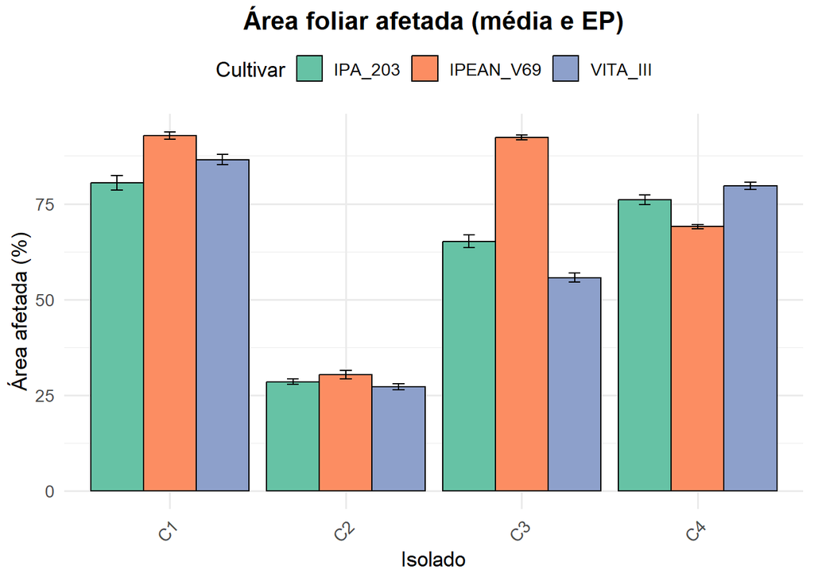

```r
# Calcular estatísticas
estatisticas <- dados %>%
  group_by(Cultivar, Isolado) %>%
  summarise(
    Media = mean(Area_Afetada),
    EP = sd(Area_Afetada) / sqrt(n()),
    .groups = "drop"
  )

# Gráfico de barras
ggplot(estatisticas, aes(x = Isolado, y = Media, fill = Cultivar)) +
  geom_col(position = position_dodge(width = 0.9), color = "black") +
  geom_errorbar(aes(ymin = Media - EP, ymax = Media + EP),
                position = position_dodge(width = 0.9),
                width = 0.2) +
  labs(
    title = "Área foliar afetada (média e EP)",
    x = "Isolado",
    y = "Área afetada (%)",
    fill = "Cultivar"
  ) +
  scale_fill_brewer(palette = "Set2") +
  theme_minimal(base_size = 13) +
  theme(
    plot.title = element_text(face = "bold", hjust = 0.5),
    axis.text.x = element_text(angle = 45, hjust = 1),
    legend.position = "top"
  )
```

## Gráfico Boxplot

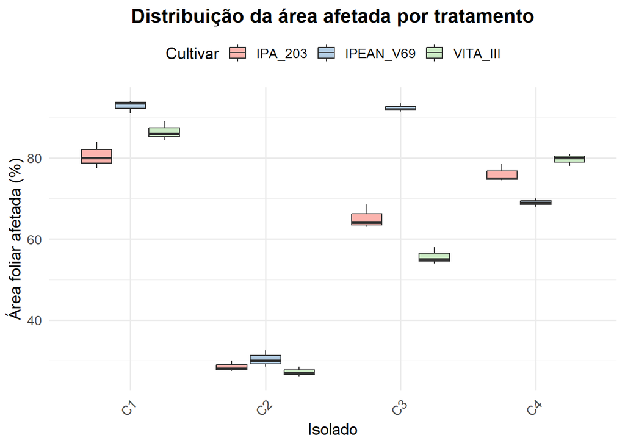

```r
ggplot(dados, aes(x = Isolado, y = Area_Afetada, fill = Cultivar)) +
  geom_boxplot(outlier.shape = 21, outlier.fill = "white", outlier.size = 2) +
  labs(
    title = "Distribuição da área afetada por tratamento",
    x = "Isolado",
    y = "Área foliar afetada (%)",
    fill = "Cultivar"
  ) +
  scale_fill_brewer(palette = "Pastel1") +
  theme_minimal(base_size = 13) +
  theme(
    plot.title = element_text(face = "bold", hjust = 0.5),
    axis.text.x = element_text(angle = 45, hjust = 1),
    legend.position = "top"
  )
```

## Gráfico de Interação

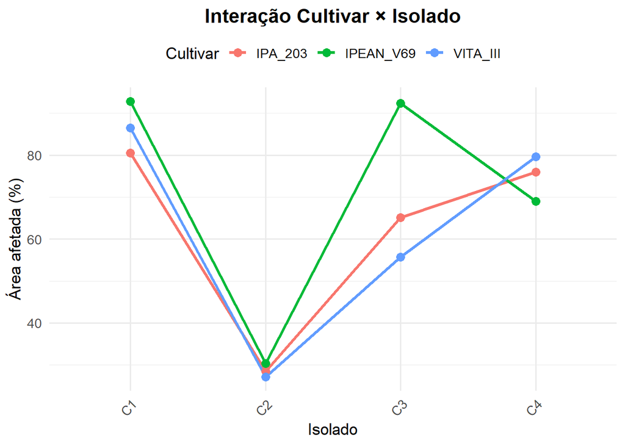

```r
# Calcular médias para interação
medias_interacao <- dados %>%
  group_by(Cultivar, Isolado) %>%
  summarise(Media = mean(Area_Afetada), .groups = "drop")

# Gráfico de interação
ggplot(medias_interacao, aes(x = Isolado, y = Media, group = Cultivar, color = Cultivar)) +
  geom_line(size = 1.2) +
  geom_point(size = 3) +
  labs(
    title = "Interação Cultivar × Isolado",
    x = "Isolado",
    y = "Área afetada (%)",
    color = "Cultivar"
  ) +
  theme_minimal(base_size = 13) +
  theme(
    plot.title = element_text(face = "bold", hjust = 0.5),
    axis.text.x = element_text(angle = 45, hjust = 1),
    legend.position = "top"
  )
```

## Hipóteses Estatísticas (ANOVA Fatorial 3×4)

### Efeito principal de Cultivar (Fator A)

- **H₀A (nula)**: As médias dos cultivares são iguais.  
  $H_{0A}: \mu_1 = \mu_2 = \mu_3$
- **H₁A (alternativa)**: Pelo menos um cultivar tem média diferente.

### Efeito principal de Isolado (Fator B)

- **H₀B (nula)**: As médias dos isolados são iguais.  
  $H_{0B}: \mu_{C1} = \mu_{C2} = \mu_{C3} = \mu_{C4}$
- **H₁B (alternativa)**: Pelo menos um isolado tem média diferente.

### Interação Cultivar × Isolado (A×B)

- **H₀AB (nula)**: Não há interação entre cultivar e isolado.  
  (O efeito de um fator é independente do outro)
- **H₁AB (alternativa)**: Existe interação.  
  (O efeito de um isolado depende do cultivar e vice-versa)

## Pressupostos

1. **Normalidade dos Erros**
   - Os resíduos do modelo devem seguir uma distribuição normal.
   - Testes: Shapiro-Wilk, histograma, QQ-plot.
2. **Homogeneidade das Variâncias (Homoscedasticidade)**
   - A variância dos erros deve ser constante entre os grupos.
   - Testes: Bartlett, Levene; gráfico de resíduos vs. valores ajustados.
3. **Independência dos Erros**
   - Os resíduos devem ser independentes entre si.
   - Verificado pelo delineamento experimental e ordem de coleta.
4. **Aditividade dos Efeitos**
   - Supõe-se que os efeitos principais e interações se somam linearmente.

## Conclusões

- Todos os efeitos foram **estatisticamente significativos** (p < 0,01).
- Há interação significativa entre cultivar e isolado.
- É necessário analisar cada combinação cultivar × isolado.
- Alguns cultivares mostram maior resistência a determinados isolados.

## Fórmulas Gerais da ANOVA Fatorial (3×4) - Só deixei aqui para me ajudar no exercício

### Modelo estatístico

$$Y_{ijk} = \mu + A_i + B_j + (AB)_{ij} + \varepsilon_{ijk}$$

### Soma de Quadrados (SQ)

- **Total**:  
  $SQ_T = \sum_{i=1}^{a} \sum_{j=1}^{b} \sum_{k=1}^{r} (Y_{ijk} - \bar{Y}...)^2$
- **Fator A (Cultivar)**:  
  $SQ_A = br \sum_{i=1}^{a} (\bar{Y}_{i..} - \bar{Y}...)^2$
- **Fator B (Isolado)**:  
  $SQ_B = ar \sum_{j=1}^{b} (\bar{Y}_{.j.} - \bar{Y}...)^2$
- **Interação A×B**:  
  $SQ_{AB} = r \sum_{i=1}^{a} \sum_{j=1}^{b} (\bar{Y}_{ij.} - \bar{Y}_{i..} - \bar{Y}_{.j.} + \bar{Y}...)^2$
- **Erro**:  
  $SQ_E = \sum_{i=1}^{a} \sum_{j=1}^{b} \sum_{k=1}^{r} (Y_{ijk} - \bar{Y}_{ij.})^2$

### Graus de Liberdade (GL)

- GL Total: $ab \cdot r - 1$
- GL A: $a - 1$
- GL B: $b - 1$
- GL AB: $(a - 1)(b - 1)$
- GL Erro: $ab(r - 1)$

### Quadrado Médio (QM)

- $QM_A = \dfrac{SQ_A}{a - 1}$
- $QM_B = \dfrac{SQ_B}{b - 1}$
- $QM_{AB} = \dfrac{SQ_{AB}}{(a - 1)(b - 1)}$
- $QM_E = \dfrac{SQ_E}{ab(r - 1)}$

### Estatísticas F

- $F_A = \dfrac{QM_A}{QM_E}$
- $F_B = \dfrac{QM_B}{QM_E}$
- $F_{AB} = \dfrac{QM_{AB}}{QM_E}$
[^1]: Universidade Estadual de Maringá, helioszjr@gmail.com